# 2 patch test case

### This notebook uses a 2 patch test case to check and explore code developed for this project.

## Loading packages and functions

```r
rm(list=ls()) #clear the workspace
library("tufte")
library("ggplot2")
library("pracma")
library("deSolve")
library("RColorBrewer")
library("colorspace")
library("wesanderson") #SUPER NICE COLOUR SCHEMES!
library("ggthemes")
setwd("C:/Users/abuga/OneDrive/Desktop/HVMcode")
```

```
The working directory was changed to C:/Users/abuga/OneDrive/Desktop/HVMcode inside a notebook chunk. The working directory will be reset when the chunk is finished running. Use the knitr root.dir option in the setup chunk to change the working directory for notebook chunks.
```

```r
source("create_landscape_func.r")
source("quasi_eq_func.r")
source("CTMC_func.r")
source("SRLM_ODE_func.r")
source("at_equilibrium_rootfunc.r")
source("dispersal_kernel_func.r")
source("CTMC_and_SRLM_func.r")
source("lambda_M_func.r")
source("metapop_size_at_QED.r")
```

## Setting our parameters

```r
#Landscape Parameters
n.patches<-2
landscape.type<-"linear"
landscape.limit<-10
patch.distribution<-"uniform"
areas.distribution<-"uniform"
areas.limit<-1
clustering.iters<-0
#Habitat Disturbance and Recovery Parameters
r.on=0.001
r.off=0.001
#Species Colonizationa and Extinction Parameters
e.rate<-0.1
c.rate<-4
#Dispersal Kernel Parameters
alpha<-0.3
self.rec<-1
gamma<-0
epsilon<-n.patches
```

## Setting up the landscape and viewing it.

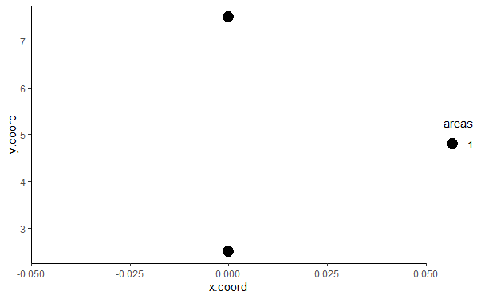

```r
landscape<-create.landscape(n.patches=n.patches, landscape.type=landscape.type, landscape.limit=landscape.limit,
                            patch.distribution=patch.distribution, areas.distribution=areas.distribution,
                            areas.limit=areas.limit, clustering.iters=clustering.iters)
print(ggplot(landscape, aes(x.coord,y.coord)) + theme_classic() + geom_point(aes(size = areas)))
```

```r
#note the scales of the areas are proportional to the specified areas but do not appear the correct size relative to the extent of the landscape/coordinates
```

## Analytic calculations of the QED, time to absorption, rate of convergence to QED vs. absorption and ratio of means distribution:

We can check these against what they should be by hand (I just used wolfram alpha to do the matrix algebra for me to save time and numbers are approximate but as you will see roughly equal to our results).

For 2 patches our generator matrix $G$ should have the form (note: Austin calls this matrix A):

$$G=
\left[\begin{array}
{rrrr}
0 & 0 & 0 & 0 \\
r.off & -(r.on+r.off) & 0 & r.on \\
r.off & 0 & -(r.on+r.off) & r.on \\
0 & r.off & r.off & -2(r.off) \\
\end{array}\right]$$
Where $C$ the submatrix of transitions between all the non-absorbing states is (note: Austin calls this A_submat):

$$C=
\left[\begin{array}
{rrr}
-(r.on+r.off) & 0 & r.on \\
0 & -(r.on+r.off) & r.on \\
r.off & r.off & -2(r.off) \\
\end{array}\right]$$

For r.on=0.001 and r.off=0.001 we should get the generator matrix ($G$):

$$G=
\left[\begin{array}
{rrrr}
0 & 0 & 0 & 0 \\
0.001 & -0.002 & 0 & 0.001 \\
0.001 & 0 & -0.002 & 0.001 \\
0 & 0.001 & 0.001 & -0.002 \\
\end{array}\right]$$

### Calculating QED

$QED$ is by definition given by the left eigenvector corresponding to the the leading eigenvalue of the submatrix $C$

$$C=
\left[\begin{array}
{rrr}
-0.002 & 0 & 0.001 \\
0 & -0.002 & 0.001 \\
0.001 & 0.001 & -0.002 \\
\end{array}\right]$$
which gives us approximately:

$$\left[\begin{array}
{rrr}
0.707 & 0.707 & 1 \\
\end{array}\right]$$

standardized by the time spent in each (or relative probability of each):

$$QED=
\left[\begin{array}
{rrr}
0.29 & 0.29 & 0.41 \\
\end{array}\right]$$

### Calculating Avergae expected time to absorption

Average time to absorption from each state ($T_A$) is simply the sum of the rows of the fundamental matrix ($N$) where $N=-C^{-1}$ scaled by a constant ($c$) given by the trace of $-C$

So since $N$ is:

$$N=
\left[\begin{array}
{rrr}
750 & 250 & 500 \\
250 & 750 & 500 \\
500 & 500 & 1000 \\
\end{array}\right]$$

and the trace of $-C$ is 0.006. Average time to absorption from each state is:

$$T_A=
\left[\begin{array}
{rrr}
9 & 9 & 12 \\
\end{array}\right]$$

### Calculating a comparison of the rate of convergence to QED versus time to absorption letting us know whether the QED is reliable or not

The rate of convergence to Absorption is given by the negative of the maximum eigenvalue of $C$ ($-\rho_1$) and rate of convergence to QED is the maximum eigenvalue of $C$ minus the next largest eigenvalue of C ($\rho_1-\rho_2$).The QED has been determined to only be useful in representing the system when $2*\rho_1/\rho_2<1$ (cite) so comparing these rates we get

$$2(-0.000585786)/(-0.002)=0.585786$$
### Calculating the ratio of means distribution

And finally the ratio of means distribution ($RMD$) is defined as $N$ divided by the sum of it’s rows and provides us with the mean porportion of time spent in each state if we were to begin in any given state and converges to the QED when the rate of convergence to absorption is long versus the rate of convergence to the QED ie. when the above equation is satisfied.

Thus, the ratio of means distribution is:

$$RMD=
\left[\begin{array}
{rrr}
0.5 & 0.167 & 0.333 \\
0.167 & 0.5 & 0.333 \\
0.25 & 0.25 & 0.5 \\
\end{array}\right]$$

### Now letting R calculate these using the function I coded:

```r
#Analytically calculating time to absorption and the Q.E.D.
###################################################################################################
QED<-quasi.eq(n.patches=n.patches, r.on=r.on, r.off=r.off)
```

```
R.methodsS3 v1.8.1 (2020-08-26 16:20:06 UTC) successfully loaded. See ?R.methodsS3 for help.
R.oo v1.24.0 (2020-08-26 16:11:58 UTC) successfully loaded. See ?R.oo for help.


R.utils v2.10.1 (2020-08-26 22:50:31 UTC) successfully loaded. See ?R.utils for help.
```

```
      [,1]   [,2]   [,3]   [,4]
[1,] 0.000  0.000  0.000  0.000
[2,] 0.001 -0.002  0.000  0.001
[3,] 0.001  0.000 -0.002  0.001
[4,] 0.000  0.001  0.001 -0.002
```

```r
QED
```

```
$QED.dist
[1] 0.2928932 0.2928932 0.4142136

$T.absorp
     [,1]
[1,]    9
[2,]    9
[3,]   12

$rate.comparison
[1] 0.5857864

$ratio.of.means.dist
          [,1]      [,2]      [,3]
[1,] 0.5000000 0.1666667 0.3333333
[2,] 0.1666667 0.5000000 0.3333333
[3,] 0.2500000 0.2500000 0.5000000
```

```r
####################################################################################################
```

And we see these give exact same output.

### Also checking the Ratio of Means Distribution converges to the QED when the QED is expected to be reliable

Now also checking the QED calculator (quasi.eq()) behaves as expected by varying r.on and r.off and looking at the rate comparison versus whether or not the ratio of means distribution converges to the QED.

1. r.off 10x r.on so should reach absorption quickly and QED estimate should be poor and not reflected in the ratio of means

```r
QED<-quasi.eq(n.patches=n.patches, r.on=0.1, r.off=1)
```

```
     [,1] [,2] [,3] [,4]
[1,]    0  0.0  0.0  0.0
[2,]    1 -1.1  0.0  0.1
[3,]    1  0.0 -1.1  0.1
[4,]    0  1.0  1.0 -2.0
```

```r
QED
```

```
$QED.dist
[1] 0.45778556 0.45778556 0.08442888

$T.absorp
     [,1]
[1,] 4.41
[2,] 4.41
[3,] 6.51

$rate.comparison
[1] 1.664675

$ratio.of.means.dist
           [,1]       [,2]       [,3]
[1,] 0.90909091 0.04329004 0.04761905
[2,] 0.04329004 0.90909091 0.04761905
[3,] 0.32258065 0.32258065 0.35483871
```

Indeed the rate comparison >1 and the ratio of means poorly reflects the QED.

2. r.on 10x r.off so probably QED should be able to be reached before absorption and reflected in the ratio of means

```r
QED<-quasi.eq(n.patches=n.patches, r.on=1, r.off=0.1)
```

```
     [,1] [,2] [,3] [,4]
[1,]  0.0  0.0  0.0  0.0
[2,]  0.1 -1.1  0.0  1.0
[3,]  0.1  0.0 -1.1  1.0
[4,]  0.0  0.1  0.1 -0.2
```

```r
QED
```

```
$QED.dist
[1] 0.07785561 0.07785561 0.84428877

$T.absorp
     [,1]
[1,]  144
[2,]  144
[3,]  156

$rate.comparison
[1] 0.02831113

$ratio.of.means.dist
           [,1]       [,2]      [,3]
[1,] 0.09090909 0.07575758 0.8333333
[2,] 0.07575758 0.09090909 0.8333333
[3,] 0.07692308 0.07692308 0.8461538
```

Indeed the rate comparison is <1 and the ratio of means distribution is closer to the QED

3. What if we make r.on 100x higher?

```r
QED<-quasi.eq(n.patches=n.patches, r.on=10, r.off=0.1)
```

```
     [,1]  [,2]  [,3] [,4]
[1,]  0.0   0.0   0.0  0.0
[2,]  0.1 -10.1   0.0 10.0
[3,]  0.1   0.0 -10.1 10.0
[4,]  0.0   0.1   0.1 -0.2
```

```r
QED
```

```
$QED.dist
[1] 0.009710569 0.009710569 0.980578862

$T.absorp
      [,1]
[1,] 10404
[2,] 10404
[3,] 10506

$rate.comparison
[1] 0.000384577

$ratio.of.means.dist
            [,1]        [,2]      [,3]
[1,] 0.009900990 0.009706853 0.9803922
[2,] 0.009706853 0.009900990 0.9803922
[3,] 0.009708738 0.009708738 0.9805825
```

Yep, now that’s super close.

At least for 2 patches I can confirm everything appears to be behaving as it should.